# STATS141SL Final Project (Persian Eye)

Jiancong Qi, Zheng Wang, Janice Li, Joy Wang, Wenxin Zhou

2/19/2020

```r
library(readxl)
library(dplyr)
library(caret)
library(e1071)
library(corrplot)
library(ggplot2)
library(readr)
library(nlme)
```

### Data Cleaning

```r
persian.UCLA = read_xlsx("PersianVCaucasianEyes.xlsx", sheet = 1)[,2:12]
persian.UCLA = na.omit(persian.UCLA)
persian.UCLA$Ethnicity = "Persian"

caucasian = read_xlsx("PersianVCaucasianEyes.xlsx", sheet = 2)[,2:12]
caucasian = na.omit(caucasian)

alldata = rbind(persian.UCLA, caucasian)

persian = read_xlsx("PersianVCaucasianEyes.xlsx", sheet = 3)[,2:9]
persian$Age = as.numeric(alldata %>% filter(Ethnicity == "Persian" & Sex == "M") %>% summarise(Age = median(Age)))
persian$Ethnicity = "Persian"

newAll = rbind(alldata[,c(11,2,5:10,1)], persian)
newTwo = alldata[,c(11,2,5:10,1)]
write.csv(newTwo,file="complete.csv")
newTwo$Ethnicity = as.factor(newTwo$Ethnicity)
newAll$Ethnicity = as.factor(newAll$Ethnicity)
persian$Ethnicity = as.factor(persian$Ethnicity)
male = newTwo %>% filter(Sex == "M")
female = newTwo %>% filter(Sex == "F")
```

###Exploratory Data Analysis

####Correlation of eye features

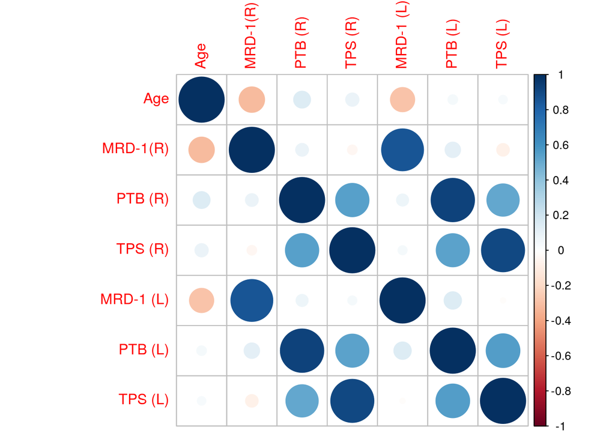

```r
# All Data
corrplot(cor(newTwo[,c(1,3:8)]))
```

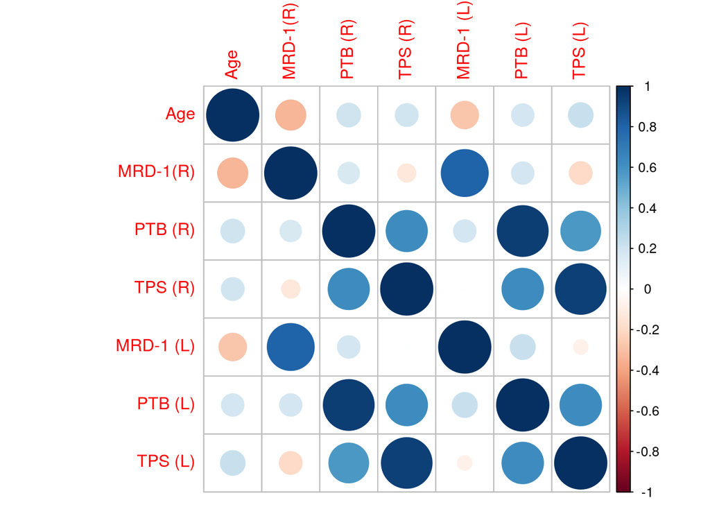

```r
# Caucasian
corrplot(cor(newTwo[which(newTwo$Ethnicity=="Caucasian"),c(1,3:8)]))
```

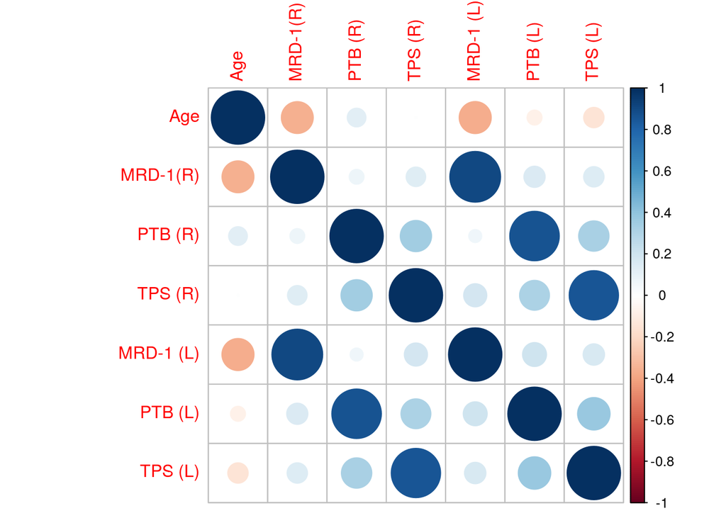

```r
# Persian
corrplot(cor(newTwo[which(newTwo$Ethnicity=="Persian"),c(1,3:8)]))
```

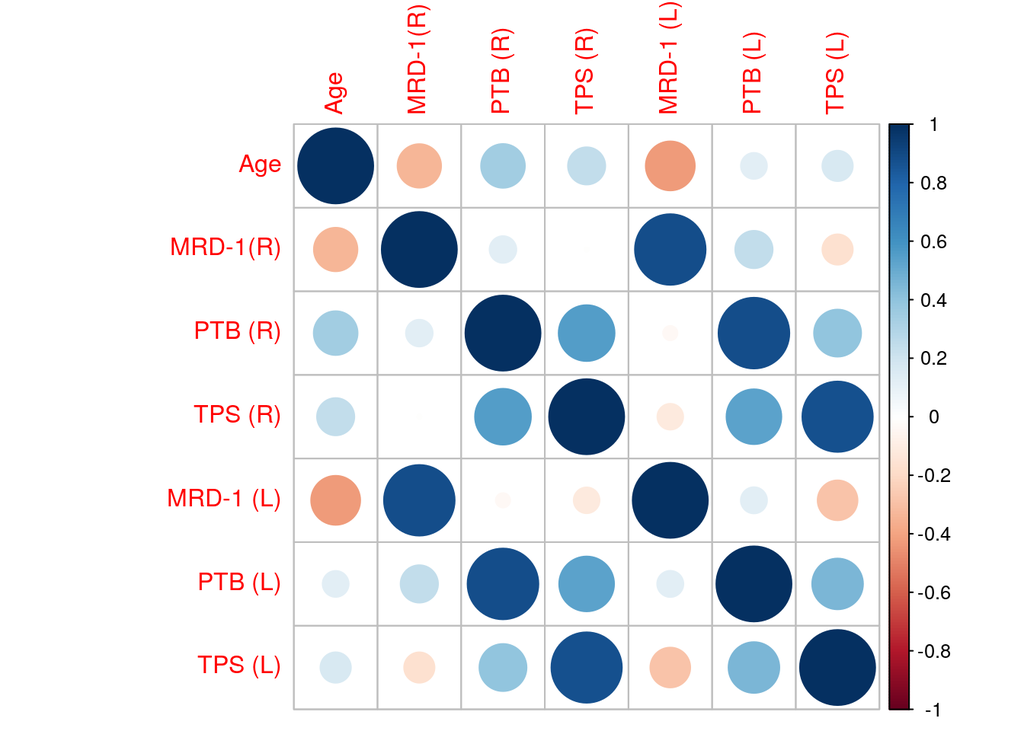

```r
# Male
corrplot(cor(male[,c(1,3:8)]))
```

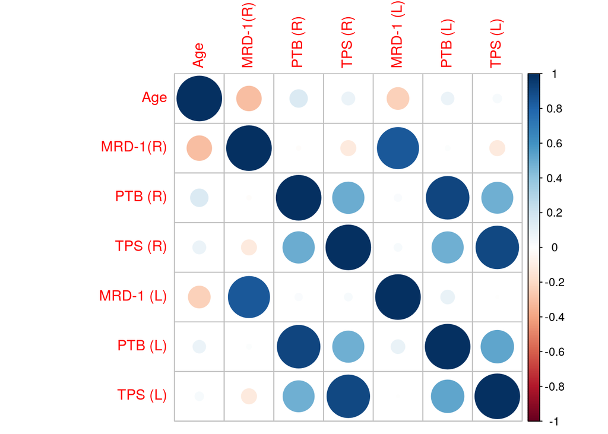

```r
# Female
corrplot(cor(female[,c(1,3:8)]))
```

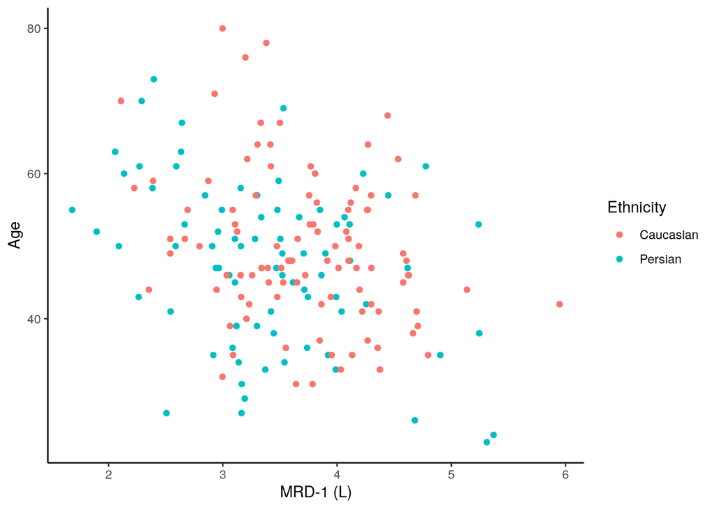

```r
#Investigate linear relation between age and MRD
ggplot(newTwo, aes(x=`MRD-1 (L)`, y=Age,fill=Ethnicity)) + geom_point(aes(color=Ethnicity)) + theme_classic()
```

####Distribution of Each Eye Feature

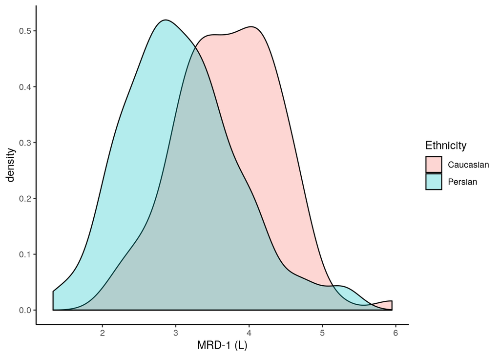

```r
ggplot(newAll, aes(x=`MRD-1 (L)`, fill=Ethnicity)) + geom_density(alpha=.3)+ theme_classic()
```

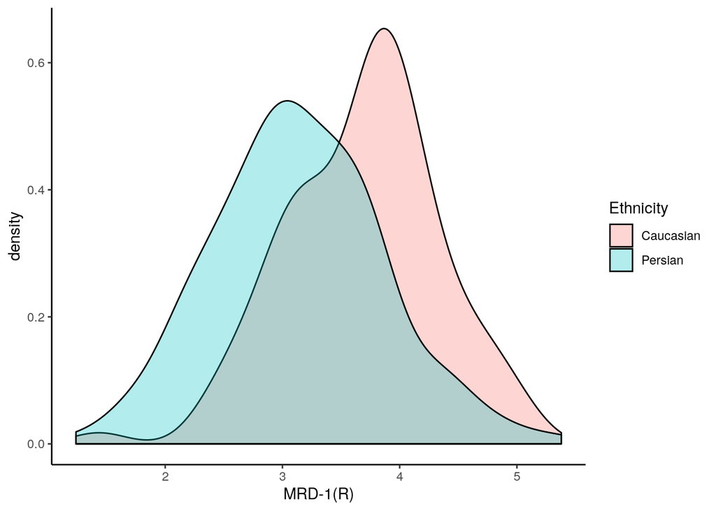

```r
ggplot(newAll, aes(x=`MRD-1(R)`, fill=Ethnicity)) + geom_density(alpha=.3)+ theme_classic()
```

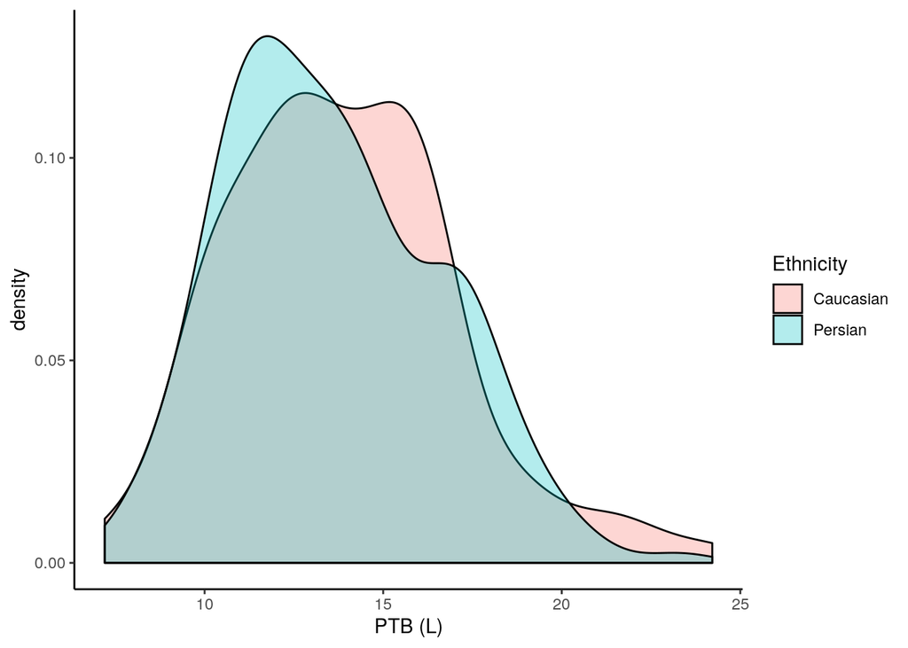

```r
ggplot(newAll, aes(x=`PTB (L)`, fill=Ethnicity)) + geom_density(alpha=.3)+ theme_classic()
```

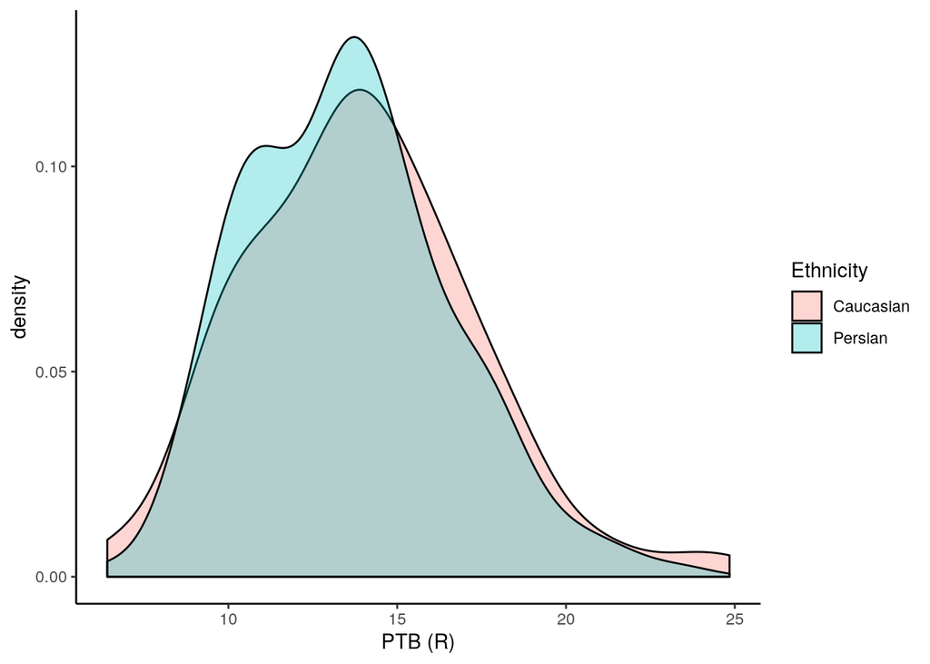

```r
ggplot(newAll, aes(x=`PTB (R)`, fill=Ethnicity)) + geom_density(alpha=.3)+ theme_classic()
```

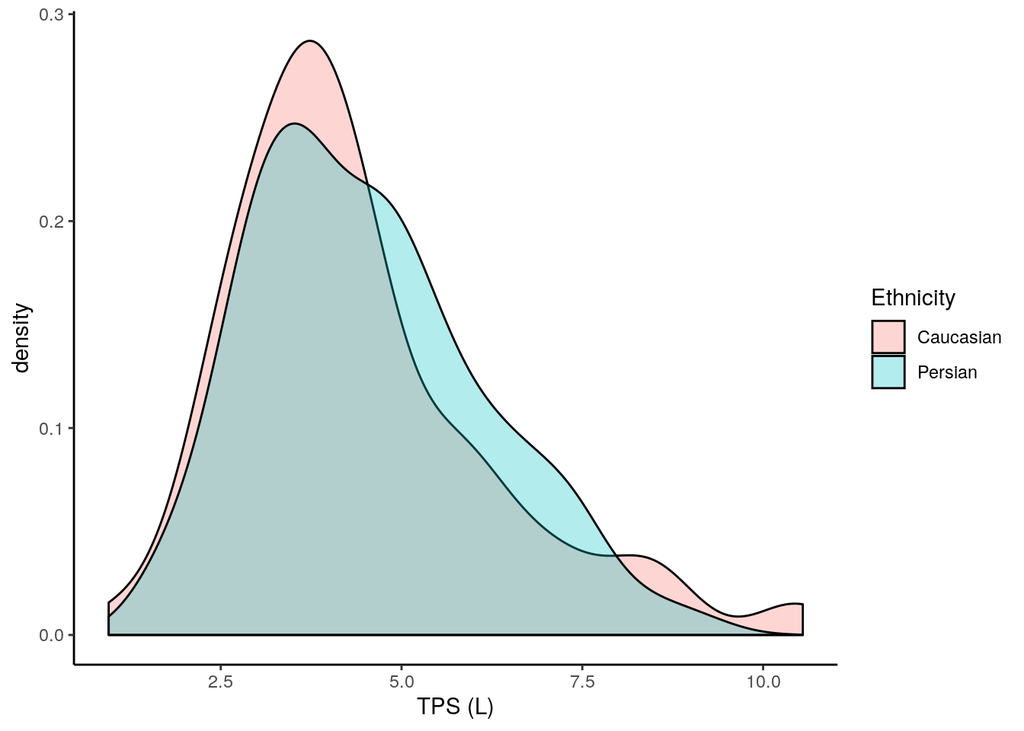

```r
ggplot(newAll, aes(x=`TPS (L)`, fill=Ethnicity)) + geom_density(alpha=.3)+ theme_classic()
```

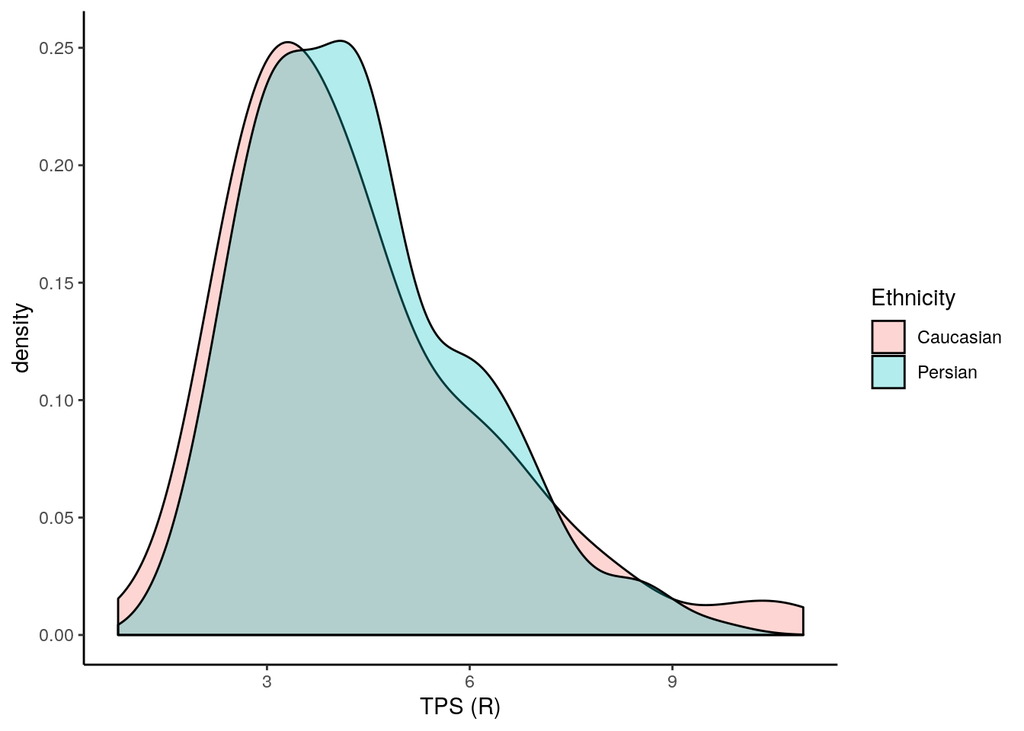

```r
ggplot(newAll, aes(x=`TPS (R)`, fill=Ethnicity)) + geom_density(alpha=.3)+ theme_classic()
```

#####Observation: 1. MRD shows Gaussian distribution, while TPS seems lognormal. PTB is ambiguous and may be either. 2. Caucasian and Persian have obviously different MRD on both left and right eyes, while TPS and PTB do not show significant difference among ethnic groups. Therefore we draw separate distribution plots for both genders below to investigate whether the difference was masked by the gender covariate.

####Distribution of Each Eye Feature, Partitioned by Gender

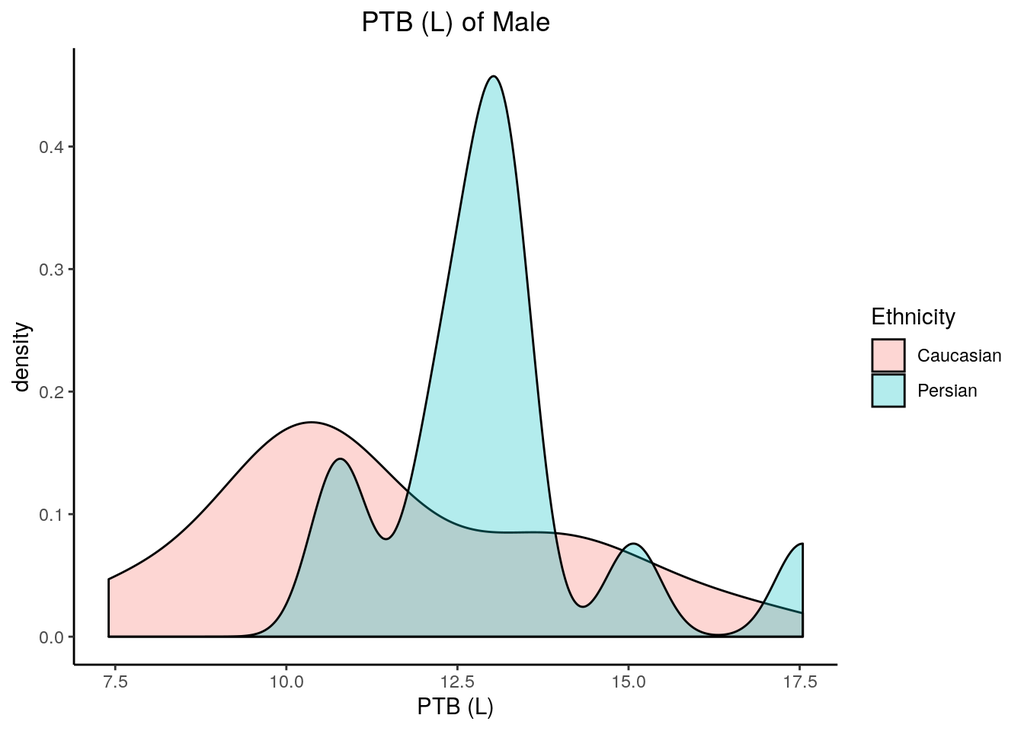

```r
ggplot(male, aes(x=`PTB (L)`, fill=Ethnicity)) + geom_density(alpha=.3)+ theme_classic()+ggtitle("PTB (L) of Male") + theme(plot.title = element_text(hjust = 0.5))
```

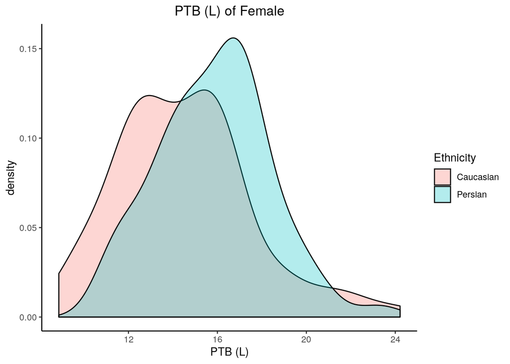

```r
ggplot(female, aes(x=`PTB (L)`, fill=Ethnicity)) + geom_density(alpha=.3)+ theme_classic()+ggtitle("PTB (L) of Female") + theme(plot.title = element_text(hjust = 0.5))
```

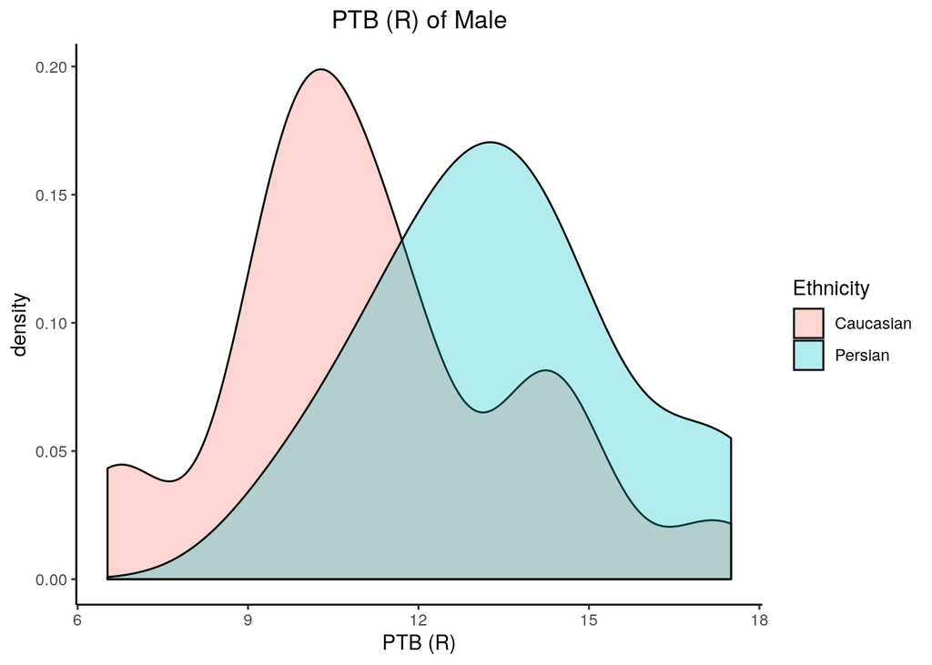

```r
ggplot(male, aes(x=`PTB (R)`, fill=Ethnicity)) + geom_density(alpha=.3)+ theme_classic()+ggtitle("PTB (R) of Male") + theme(plot.title = element_text(hjust = 0.5))
```

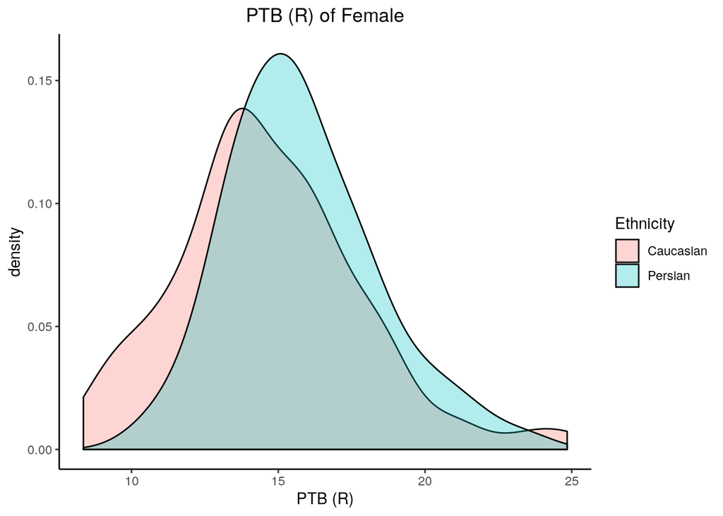

```r
ggplot(female, aes(x=`PTB (R)`, fill=Ethnicity)) + geom_density(alpha=.3)+ theme_classic()+ggtitle("PTB (R) of Female") + theme(plot.title = element_text(hjust = 0.5))
```

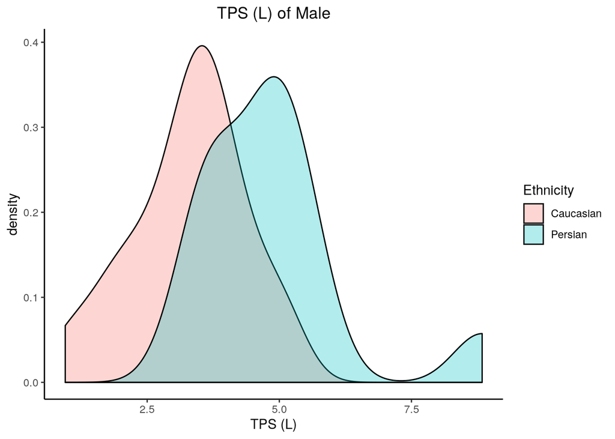

```r
ggplot(male, aes(x=`TPS (L)`, fill=Ethnicity)) + geom_density(alpha=.3)+ theme_classic()+ggtitle("TPS (L) of Male") + theme(plot.title = element_text(hjust = 0.5))
```

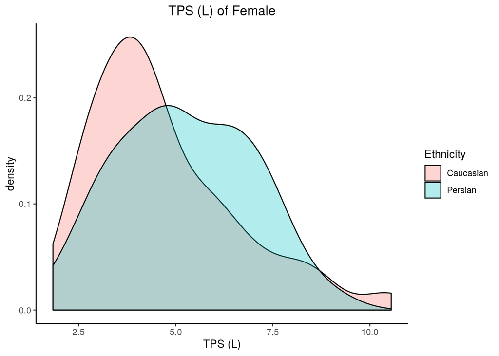

```r
ggplot(female, aes(x=`TPS (L)`, fill=Ethnicity)) + geom_density(alpha=.3)+ theme_classic()+ggtitle("TPS (L) of Female") + theme(plot.title = element_text(hjust = 0.5))
```

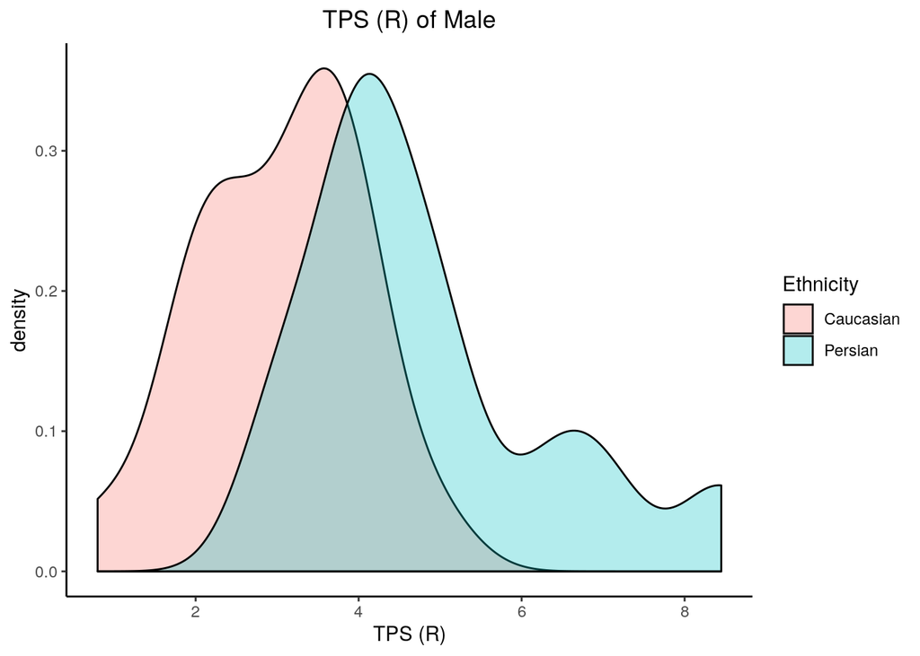

```r
ggplot(male, aes(x=`TPS (R)`, fill=Ethnicity)) + geom_density(alpha=.3)+ theme_classic()+ggtitle("TPS (R) of Male") + theme(plot.title = element_text(hjust = 0.5))
```

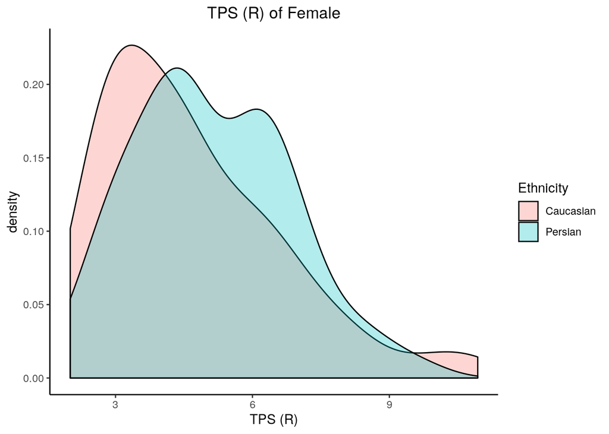

```r
ggplot(female, aes(x=`TPS (R)`, fill=Ethnicity)) + geom_density(alpha=.3)+ theme_classic()+ggtitle("TPS (R) of Female") + theme(plot.title = element_text(hjust = 0.5))
```

#####Observation: 1. After splitting the data by gender, both PTB and TPS show obvious differences between the ethnic groups. Therefore, we should create separate models for both genders instead of neglecting the covariate. 2. The distribution of PTB(L) for Male looks abnormal. Since PTB(R), which is highly correlated to PTB(L), shows a normal Gaussian distribution, we assume that the exotic shape arised due to the small sample size(only 21 Caucasions and 13 Persians in this sample).

####Distribution of Variables Derived from Eye Features, Partitioned by Gender (Taking right eyes as examples)

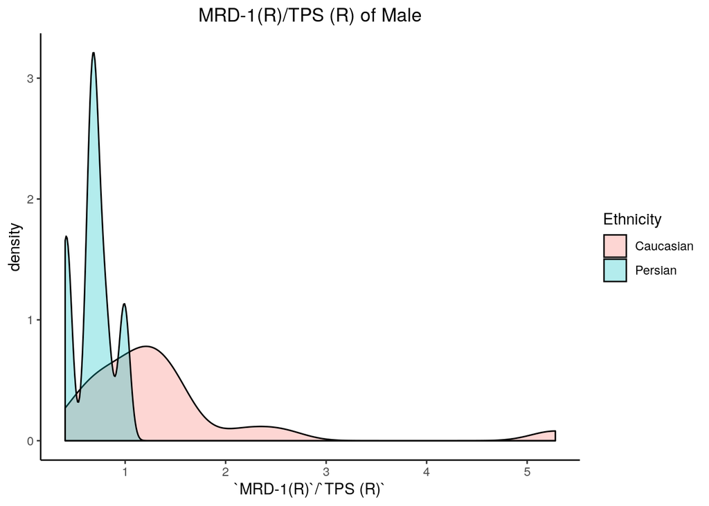

```r
ggplot(male, aes(x=`MRD-1(R)`/`TPS (R)`, fill=Ethnicity)) + geom_density(alpha=.3)+ theme_classic()+ggtitle("MRD-1(R)/TPS (R) of Male") + theme(plot.title = element_text(hjust = 0.5))
```

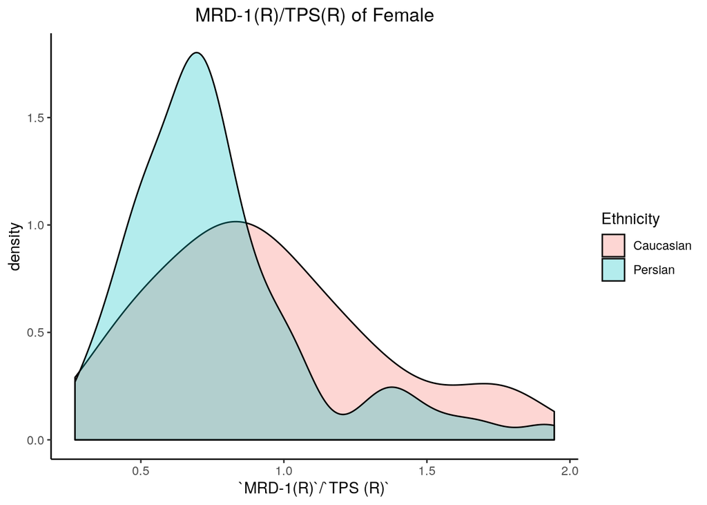

```r
ggplot(female, aes(x=`MRD-1(R)`/`TPS (R)`, fill=Ethnicity)) + geom_density(alpha=.3)+ theme_classic()+ggtitle("MRD-1(R)/TPS(R) of Female") + theme(plot.title = element_text(hjust = 0.5))
```

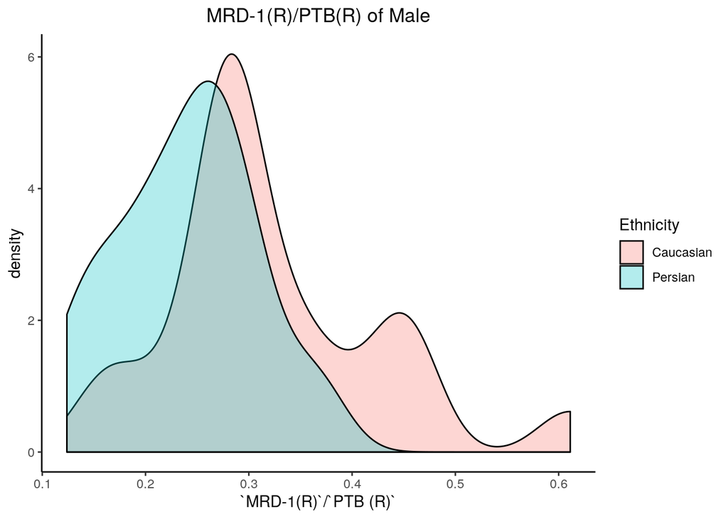

```r
ggplot(male, aes(x=`MRD-1(R)`/`PTB (R)`, fill=Ethnicity)) + geom_density(alpha=.3)+ theme_classic()+ggtitle("MRD-1(R)/PTB(R) of Male") + theme(plot.title = element_text(hjust = 0.5))
```

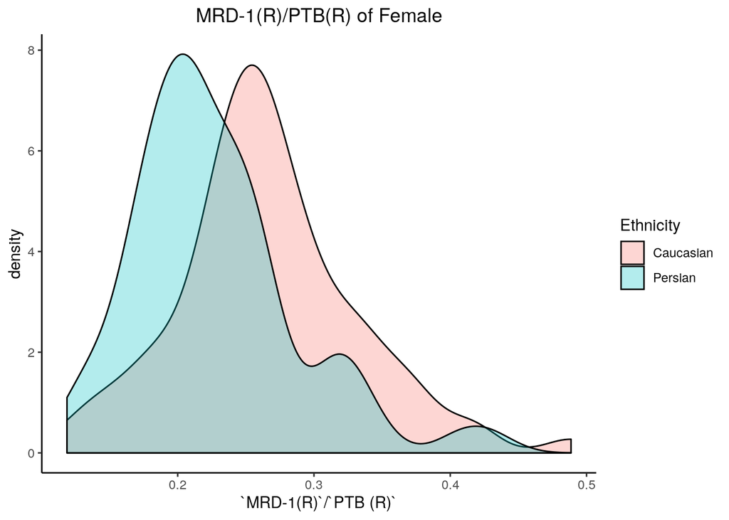

```r
ggplot(female, aes(x=`MRD-1(R)`/`PTB (R)`, fill=Ethnicity)) + geom_density(alpha=.3)+ theme_classic()+ggtitle("MRD-1(R)/PTB(R) of Female") + theme(plot.title = element_text(hjust = 0.5))
```

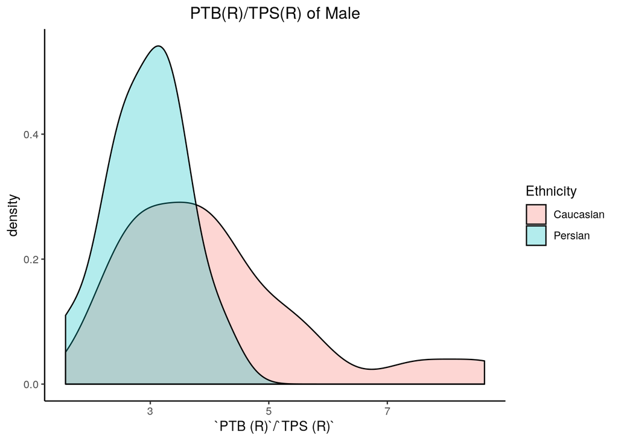

```r
ggplot(male, aes(x=`PTB (R)`/`TPS (R)`, fill=Ethnicity)) + geom_density(alpha=.3)+ theme_classic()+ggtitle("PTB(R)/TPS(R) of Male") + theme(plot.title = element_text(hjust = 0.5))
```

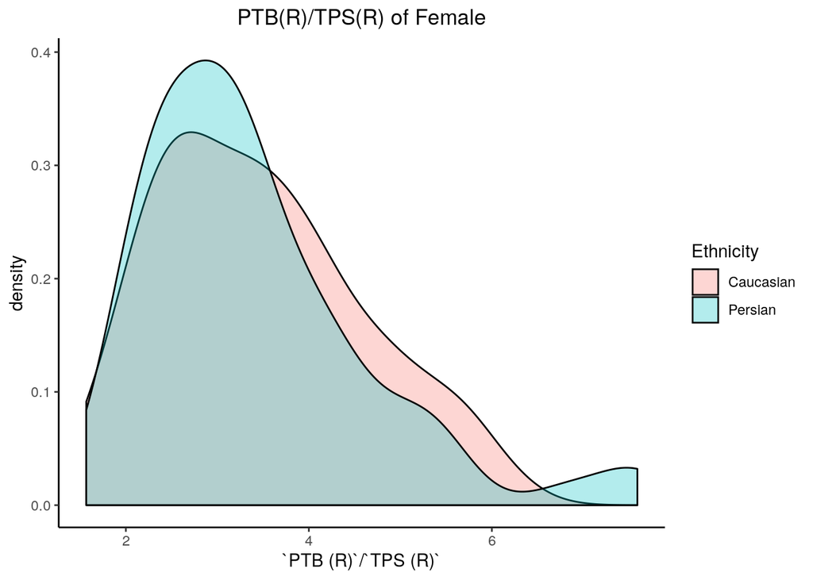

```r
ggplot(female, aes(x=`PTB (R)`/`TPS (R)`, fill=Ethnicity)) + geom_density(alpha=.3)+ theme_classic()+ggtitle("PTB(R)/TPS(R) of Female") + theme(plot.title = element_text(hjust = 0.5))
```

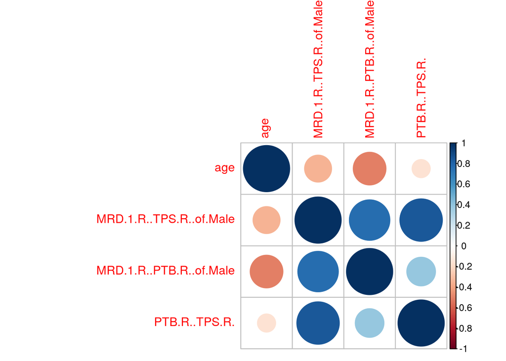

```r
dat_male=data.frame(age=male$Age,'MRD-1(R)/TPS(R) of Male'=male$`MRD-1(R)`/male$`TPS (R)`,'MRD-1(R)/PTB(R) of Male'=male$`MRD-1(R)`/male$`PTB (R)`,'PTB(R)/TPS(R)'=male$`PTB (R)`/male$`TPS (R)`)
corrplot(cor(dat_male))
```

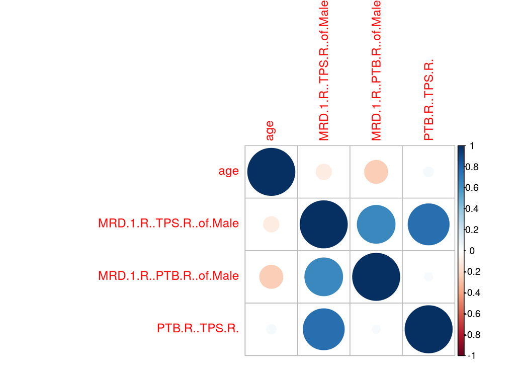

```r
dat_female=data.frame(age=female$Age,'MRD-1(R)/TPS(R) of Male'=female$`MRD-1(R)`/female$`TPS (R)`,'MRD-1(R)/PTB(R) of Male'=female$`MRD-1(R)`/female$`PTB (R)`,'PTB(R)/TPS(R)'=female$`PTB (R)`/female$`TPS (R)`)
corrplot(cor(dat_female))
```

The above two observations suggest that we can potentially predict the two derived variables, MRD/TPS and MRD/PTB, with gender and age.

###CV Split

```r
smp_siz = floor(0.8*nrow(newTwo))
set.seed(684323)
train_ind = sample(seq_len(nrow(newTwo)),size = smp_siz)
train = newTwo[train_ind,]
test = newTwo[-train_ind,]

write.csv(train,file="ann_train.csv")
write.csv(test,file="ann_test.csv")

smp_siz = floor(0.8*nrow(male))
train_ind = sample(seq_len(nrow(male)),size = smp_siz)
trainMale = male[train_ind,]
testMale = male[-train_ind,]

smp_siz = floor(0.8*nrow(female))
train_ind = sample(seq_len(nrow(female)),size = smp_siz)
trainFemale = female[train_ind,]
testFemale = female[-train_ind,]
```

###Data Modeling to Predict Ethnicity

```r
# All
m1 = glm(Ethnicity ~ `MRD-1 (L)` + `PTB (L)` + Age + Sex, data = train, family = "binomial")

m2 = glm(Ethnicity ~ `MRD-1 (L)` * `TPS (L)` * `PTB (L)` + Age + Sex, data = train, family = "binomial")

m3 = glm(Ethnicity ~ `MRD-1 (L)` * `TPS (L)` * `PTB (L)` * Age * Sex, data = train, family = "binomial")
# Male/Female
m4 = glm(Ethnicity ~ `MRD-1 (L)` + `PTB (L)` + Age, data = trainFemale , family = "binomial")

m5 = glm(Ethnicity ~ `MRD-1 (L)` + `PTB (L)` + Age, data = trainMale , family = "binomial")
```

```r
summary(m1)
```

```
##
## Call:
## glm(formula = Ethnicity ~ `MRD-1 (L)` + `PTB (L)` + Age + Sex,
##     family = "binomial", data = train)
##
## Deviance Residuals:
##     Min       1Q   Median       3Q      Max
## -1.8462  -0.9224  -0.5755   1.0132   2.2748
##
## Coefficients:
##             Estimate Std. Error z value Pr(>|z|)
## (Intercept)  1.09481    1.62756   0.673  0.50116
## `MRD-1 (L)` -0.77530    0.27240  -2.846  0.00442 **
## `PTB (L)`    0.27675    0.07442   3.719  0.00020 ***
## Age         -0.05665    0.01933  -2.931  0.00338 **
## SexM         0.55207    0.53512   1.032  0.30222
## ---
## Signif. codes:  0 '***' 0.001 '**' 0.01 '*' 0.05 '.' 0.1 ' ' 1
##
## (Dispersion parameter for binomial family taken to be 1)
##
##     Null deviance: 195.71  on 142  degrees of freedom
## Residual deviance: 169.46  on 138  degrees of freedom
## AIC: 179.46
##
## Number of Fisher Scoring iterations: 3
```

```r
summary(m2)
```

```
##
## Call:
## glm(formula = Ethnicity ~ `MRD-1 (L)` * `TPS (L)` * `PTB (L)` +
##     Age + Sex, family = "binomial", data = train)
##
## Deviance Residuals:
##     Min       1Q   Median       3Q      Max
## -1.7933  -0.9319  -0.3380   0.9400   2.3092
##
## Coefficients:
##                                 Estimate Std. Error z value Pr(>|z|)
## (Intercept)                      2.77742   17.73798   0.157   0.8756
## `MRD-1 (L)`                     -4.29190    5.18386  -0.828   0.4077
## `TPS (L)`                       -2.02475    3.35716  -0.603   0.5464
## `PTB (L)`                        0.34653    1.21932   0.284   0.7763
## Age                             -0.04817    0.02042  -2.359   0.0183 *
## SexM                             0.84336    0.59050   1.428   0.1532
## `MRD-1 (L)`:`TPS (L)`            1.18094    0.99542   1.186   0.2355
## `MRD-1 (L)`:`PTB (L)`            0.16432    0.35491   0.463   0.6434
## `TPS (L)`:`PTB (L)`              0.09042    0.21537   0.420   0.6746
## `MRD-1 (L)`:`TPS (L)`:`PTB (L)` -0.06261    0.06362  -0.984   0.3250
## ---
## Signif. codes:  0 '***' 0.001 '**' 0.01 '*' 0.05 '.' 0.1 ' ' 1
##
## (Dispersion parameter for binomial family taken to be 1)
##
##     Null deviance: 195.71  on 142  degrees of freedom
## Residual deviance: 153.91  on 133  degrees of freedom
## AIC: 173.91
##
## Number of Fisher Scoring iterations: 5
```

```r
summary(m3)
```

```
##
## Call:
## glm(formula = Ethnicity ~ `MRD-1 (L)` * `TPS (L)` * `PTB (L)` *
##     Age * Sex, family = "binomial", data = train)
##
## Deviance Residuals:
##      Min        1Q    Median        3Q       Max
## -2.46378  -0.62509  -0.00009   0.56636   2.10746
##
## Coefficients:
##                                            Estimate Std. Error z value Pr(>|z|)
## (Intercept)                               1.589e+02  1.940e+02   0.819    0.413
## `MRD-1 (L)`                              -2.503e+01  5.658e+01  -0.442    0.658
## `TPS (L)`                                -2.247e+01  3.331e+01  -0.674    0.500
## `PTB (L)`                                -1.414e+01  1.351e+01  -1.047    0.295
## Age                                      -1.741e+00  3.927e+00  -0.443    0.657
## SexM                                      2.331e+04  8.997e+06   0.003    0.998
## `MRD-1 (L)`:`TPS (L)`                     2.211e+00  9.932e+00   0.223    0.824
## `MRD-1 (L)`:`PTB (L)`                     2.667e+00  3.907e+00   0.682    0.495
## `TPS (L)`:`PTB (L)`                       2.326e+00  2.221e+00   1.048    0.295
## `MRD-1 (L)`:Age                           3.115e-02  1.172e+00   0.027    0.979
## `TPS (L)`:Age                             2.997e-03  6.684e-01   0.004    0.996
## `PTB (L)`:Age                             1.951e-01  2.689e-01   0.725    0.468
## `MRD-1 (L)`:SexM                         -3.866e+03  2.397e+06  -0.002    0.999
## `TPS (L)`:SexM                           -1.651e+04  2.552e+06  -0.006    0.995
## `PTB (L)`:SexM                           -1.552e+03  7.104e+05  -0.002    0.998
## Age:SexM                                 -9.583e+01  1.739e+05  -0.001    1.000
## `MRD-1 (L)`:`TPS (L)`:`PTB (L)`          -3.657e-01  6.527e-01  -0.560    0.575
## `MRD-1 (L)`:`TPS (L)`:Age                 8.506e-02  2.082e-01   0.409    0.683
## `MRD-1 (L)`:`PTB (L)`:Age                -2.490e-02  7.951e-02  -0.313    0.754
## `TPS (L)`:`PTB (L)`:Age                  -1.761e-02  4.307e-02  -0.409    0.683
## `MRD-1 (L)`:`TPS (L)`:SexM                4.059e+03  6.548e+05   0.006    0.995
## `MRD-1 (L)`:`PTB (L)`:SexM                2.154e+02  1.929e+05   0.001    0.999
## `TPS (L)`:`PTB (L)`:SexM                  1.207e+03  1.966e+05   0.006    0.995
## `MRD-1 (L)`:Age:SexM                     -3.542e+01  4.771e+04  -0.001    0.999
## `TPS (L)`:Age:SexM                        2.139e+02  4.614e+04   0.005    0.996
## `PTB (L)`:Age:SexM                        2.924e+00  1.377e+04   0.000    1.000
## `MRD-1 (L)`:`TPS (L)`:`PTB (L)`:Age      -9.541e-04  1.333e-02  -0.072    0.943
## `MRD-1 (L)`:`TPS (L)`:`PTB (L)`:SexM     -2.929e+02  5.104e+04  -0.006    0.995
## `MRD-1 (L)`:`TPS (L)`:Age:SexM           -4.608e+01  1.195e+04  -0.004    0.997
## `MRD-1 (L)`:`PTB (L)`:Age:SexM            4.246e+00  3.850e+03   0.001    0.999
## `TPS (L)`:`PTB (L)`:Age:SexM             -1.534e+01  3.572e+03  -0.004    0.997
## `MRD-1 (L)`:`TPS (L)`:`PTB (L)`:Age:SexM  3.198e+00  9.393e+02   0.003    0.997
##
## (Dispersion parameter for binomial family taken to be 1)
##
##     Null deviance: 195.71  on 142  degrees of freedom
## Residual deviance: 103.07  on 111  degrees of freedom
## AIC: 167.07
##
## Number of Fisher Scoring iterations: 20
```

```r
summary(m4)
```

```
##
## Call:
## glm(formula = Ethnicity ~ `MRD-1 (L)` + `PTB (L)` + Age, family = "binomial",
##     data = trainFemale)
##
## Deviance Residuals:
##     Min       1Q   Median       3Q      Max
## -1.7373  -0.9825  -0.5647   0.9891   2.2924
##
## Coefficients:
##             Estimate Std. Error z value Pr(>|z|)
## (Intercept)  2.45170    1.79650   1.365  0.17234
## `MRD-1 (L)` -0.96297    0.31757  -3.032  0.00243 **
## `PTB (L)`    0.23497    0.08084   2.907  0.00365 **
## Age         -0.05466    0.02084  -2.623  0.00871 **
## ---
## Signif. codes:  0 '***' 0.001 '**' 0.01 '*' 0.05 '.' 0.1 ' ' 1
##
## (Dispersion parameter for binomial family taken to be 1)
##
##     Null deviance: 160.26  on 115  degrees of freedom
## Residual deviance: 141.36  on 112  degrees of freedom
## AIC: 149.36
##
## Number of Fisher Scoring iterations: 4
```

```r
summary(m5)
```

```
##
## Call:
## glm(formula = Ethnicity ~ `MRD-1 (L)` + `PTB (L)` + Age, family = "binomial",
##     data = trainMale)
##
## Deviance Residuals:
##     Min       1Q   Median       3Q      Max
## -1.6092  -0.8362  -0.3328   0.8021   2.0800
##
## Coefficients:
##              Estimate Std. Error z value Pr(>|z|)
## (Intercept) -3.016583   3.483627  -0.866   0.3865
## `MRD-1 (L)` -1.138371   0.673937  -1.689   0.0912 .
## `PTB (L)`    0.479599   0.227485   2.108   0.0350 *
## Age          0.008509   0.042754   0.199   0.8422
## ---
## Signif. codes:  0 '***' 0.001 '**' 0.01 '*' 0.05 '.' 0.1 ' ' 1
##
## (Dispersion parameter for binomial family taken to be 1)
##
##     Null deviance: 36.499  on 26  degrees of freedom
## Residual deviance: 27.509  on 23  degrees of freedom
## AIC: 35.509
##
## Number of Fisher Scoring iterations: 5
```

```r
confusionMatrix(table(predict(m1,test[,1:8],type = 'response') >=0.5,test$Ethnicity=="Persian"))[3]
```

```
## $overall
##       Accuracy          Kappa  AccuracyLower  AccuracyUpper   AccuracyNull
##     0.63888889     0.27777778     0.46220900     0.79177705     0.50000000
## AccuracyPValue  McnemarPValue
##     0.06624908     0.09609233
```

```r
confusionMatrix(table(predict(m2,test[,1:8],type = 'response') >=0.5,test$Ethnicity=="Persian"))[3]
```

```
## $overall
##       Accuracy          Kappa  AccuracyLower  AccuracyUpper   AccuracyNull
##     0.63888889     0.27777778     0.46220900     0.79177705     0.50000000
## AccuracyPValue  McnemarPValue
##     0.06624908     1.00000000
```

```r
confusionMatrix(table(predict(m3,test[,1:8],type = 'response') >=0.5,test$Ethnicity=="Persian"))[3]
```

```
## $overall
##       Accuracy          Kappa  AccuracyLower  AccuracyUpper   AccuracyNull
##      0.5555556      0.1111111      0.3809768      0.7206458      0.5000000
## AccuracyPValue  McnemarPValue
##      0.3088597      0.8025873
```

```r
confusionMatrix(table(predict(m4,testFemale[,1:8],type = 'response') >=0.5,testFemale$Ethnicity=="Persian"))[3]
```

```
## $overall
##       Accuracy          Kappa  AccuracyLower  AccuracyUpper   AccuracyNull
##     0.72413793     0.44230769     0.52761552     0.87265989     0.55172414
## AccuracyPValue  McnemarPValue
##     0.04436977     1.00000000
```

```r
confusionMatrix(table(predict(m5,testMale[,1:8],type = 'response') >=0.5,testMale$Ethnicity=="Persian"))[3]
```

```
## $overall
##       Accuracy          Kappa  AccuracyLower  AccuracyUpper   AccuracyNull
##     0.57142857     0.08695652     0.18405157     0.90101172     0.71428571
## AccuracyPValue  McnemarPValue
##     0.89172636     1.00000000
```

```bash
# run the neural network as a reference to see performance
# of the logistic regression model
python3 FinalProj_ann.py
```

```
## Epoch: 1
## Train Loss: 0.688 | Train Acc: 0.57
## Val. Loss: 0.694 |  Val. Acc: 0.50
## Epoch: 2
## Train Loss: 0.684 | Train Acc: 0.57
## Val. Loss: 0.695 |  Val. Acc: 0.50
## Epoch: 3
## Train Loss: 0.680 | Train Acc: 0.56
## Val. Loss: 0.696 |  Val. Acc: 0.50
## Epoch: 4
## Train Loss: 0.671 | Train Acc: 0.57
## Val. Loss: 0.697 |  Val. Acc: 0.50
## Epoch: 5
## Train Loss: 0.658 | Train Acc: 0.57
## Val. Loss: 0.701 |  Val. Acc: 0.50
## Epoch: 6
## Train Loss: 0.638 | Train Acc: 0.64
## Val. Loss: 0.709 |  Val. Acc: 0.53
## Epoch: 7
## Train Loss: 0.623 | Train Acc: 0.70
## Val. Loss: 0.718 |  Val. Acc: 0.47
## Epoch: 8
## Train Loss: 0.603 | Train Acc: 0.70
## Val. Loss: 0.726 |  Val. Acc: 0.47
## Epoch: 9
## Train Loss: 0.592 | Train Acc: 0.71
## Val. Loss: 0.737 |  Val. Acc: 0.50
## Epoch: 10
## Train Loss: 0.585 | Train Acc: 0.71
## Val. Loss: 0.720 |  Val. Acc: 0.53
## Epoch: 11
## Train Loss: 0.583 | Train Acc: 0.73
## Val. Loss: 0.718 |  Val. Acc: 0.64
## Epoch: 12
## Train Loss: 0.571 | Train Acc: 0.73
## Val. Loss: 0.707 |  Val. Acc: 0.56
## Epoch: 13
## Train Loss: 0.579 | Train Acc: 0.71
## Val. Loss: 0.691 |  Val. Acc: 0.53
## Epoch: 14
```

[output cut: 20 more lines]

```
## Epoch: 21
## Train Loss: 0.531 | Train Acc: 0.79
## Val. Loss: 0.626 |  Val. Acc: 0.69
## Epoch: 22
## Train Loss: 0.521 | Train Acc: 0.79
## Val. Loss: 0.654 |  Val. Acc: 0.61
## Epoch: 23
## Train Loss: 0.532 | Train Acc: 0.78
## Val. Loss: 0.692 |  Val. Acc: 0.61
## Epoch: 24
## Train Loss: 0.512 | Train Acc: 0.81
## Val. Loss: 0.629 |  Val. Acc: 0.64
## Epoch: 25
## Train Loss: 0.511 | Train Acc: 0.79
## Val. Loss: 0.633 |  Val. Acc: 0.69
```

```bash
# run python script to prepare
# data for the next part
python3 reorganize.py
```

```r
## run random effect model to see how the measures are differed by Ethnicity
random_effect_data <- read_csv("./random_effect_data.csv")

random_effect_MRD = lme(`MRD` ~ Ethnicity + Sex + Age, random_effect_data, random=~1|Person)
random_effect_PTB = lme(`PTB` ~ Ethnicity + Sex + Age, random_effect_data, random=~1|Person)
random_effect_TPS = lme(`TPS` ~ Ethnicity + Sex + Age, random_effect_data, random=~1|Person)
random_effect_MRD_TPS = lme(`MRD`/`TPS` ~ Ethnicity + Sex + Age, random_effect_data, random=~1|Person)
random_effect_MRD_PTB = lme(`MRD`/`PTB` ~ Ethnicity + Sex + Age, random_effect_data, random=~1|Person)
random_effect_PTB_TPS = lme(`PTB`/`TPS` ~ Ethnicity + Sex + Age, random_effect_data, random=~1|Person)

summary(random_effect_MRD)
```

```
## Linear mixed-effects model fit by REML
##  Data: random_effect_data
##        AIC      BIC    logLik
##   541.4194 564.6352 -264.7097
##
## Random effects:
##  Formula: ~1 | Person
##         (Intercept)  Residual
## StdDev:   0.6066897 0.2739373
##
## Fixed effects: MRD ~ Ethnicity + Sex + Age
##                      Value  Std.Error  DF   t-value p-value
## (Intercept)       4.802078 0.22957386 179 20.917355  0.0000
## EthnicityPersian -0.344793 0.09640895 175 -3.576364  0.0005
## SexM             -0.262930 0.12195181 175 -2.156016  0.0324
## Age              -0.021038 0.00444844 175 -4.729360  0.0000
##  Correlation:
##                  (Intr) EthncP SexM
## EthnicityPersian -0.287
## SexM             -0.039  0.055
## Age              -0.954  0.099 -0.077
##
## Standardized Within-Group Residuals:
##         Min          Q1         Med          Q3         Max
## -2.37750703 -0.46415988 -0.01637356  0.47419667  2.59684014
##
## Number of Observations: 358
## Number of Groups: 179
```

```r
summary(random_effect_PTB)
```

```
## Linear mixed-effects model fit by REML
##  Data: random_effect_data
##        AIC     BIC    logLik
##   1457.244 1480.46 -722.6219
##
## Random effects:
##  Formula: ~1 | Person
##         (Intercept)  Residual
## StdDev:    2.598748 0.8709218
##
## Fixed effects: PTB ~ Ethnicity + Sex + Age
##                      Value Std.Error  DF   t-value p-value
## (Intercept)      12.401830 0.9627319 179 12.881915  0.0000
## EthnicityPersian  1.459616 0.4042968 175  3.610259  0.0004
## SexM             -3.075288 0.5114123 175 -6.013325  0.0000
## Age               0.043172 0.0186548 175  2.314280  0.0218
##  Correlation:
##                  (Intr) EthncP SexM
## EthnicityPersian -0.287
## SexM             -0.039  0.055
## Age              -0.954  0.099 -0.077
##
## Standardized Within-Group Residuals:
##         Min          Q1         Med          Q3         Max
## -2.53278138 -0.47266204  0.03845594  0.43092830  2.60315647
##
## Number of Observations: 358
## Number of Groups: 179
```

```r
summary(random_effect_TPS)
```

```
## Linear mixed-effects model fit by REML
##  Data: random_effect_data
##        AIC      BIC    logLik
##   1136.649 1159.865 -562.3245
##
## Random effects:
##  Formula: ~1 | Person
##         (Intercept)  Residual
## StdDev:    1.651334 0.5540683
##
## Fixed effects: TPS ~ Ethnicity + Sex + Age
##                      Value Std.Error  DF   t-value p-value
## (Intercept)       3.738484 0.6117915 179  6.110717  0.0000
## EthnicityPersian  0.738228 0.2569203 175  2.873375  0.0046
## SexM             -1.093731 0.3249894 175 -3.365437  0.0009
## Age               0.017414 0.0118546 175  1.468964  0.1436
##  Correlation:
##                  (Intr) EthncP SexM
## EthnicityPersian -0.287
## SexM             -0.039  0.055
## Age              -0.954  0.099 -0.077
##
## Standardized Within-Group Residuals:
##         Min          Q1         Med          Q3         Max
## -2.18648376 -0.37783117 -0.05945532  0.40679160  2.24929097
##
## Number of Observations: 358
## Number of Groups: 179
```

```r
summary(random_effect_MRD_TPS)
```

```
## Linear mixed-effects model fit by REML
##  Data: random_effect_data
##        AIC      BIC    logLik
##   243.7876 267.0034 -115.8938
##
## Random effects:
##  Formula: ~1 | Person
##         (Intercept)  Residual
## StdDev:   0.4262671 0.1701327
##
## Fixed effects: MRD/TPS ~ Ethnicity + Sex + Age
##                       Value  Std.Error  DF   t-value p-value
## (Intercept)       1.4240643 0.15966152 179  8.919271  0.0000
## EthnicityPersian -0.2899920 0.06704944 175 -4.325047  0.0000
## SexM              0.2357888 0.08481371 175  2.780079  0.0060
## Age              -0.0091361 0.00309375 175 -2.953069  0.0036
##  Correlation:
##                  (Intr) EthncP SexM
## EthnicityPersian -0.287
## SexM             -0.039  0.055
## Age              -0.954  0.099 -0.077
##
## Standardized Within-Group Residuals:
##         Min          Q1         Med          Q3         Max
## -2.66366799 -0.36061584 -0.05816786  0.28638918  4.75474728
##
## Number of Observations: 358
## Number of Groups: 179
```

```r
summary(random_effect_MRD_PTB)
```

```
## Linear mixed-effects model fit by REML
##  Data: random_effect_data
##         AIC       BIC   logLik
##   -1150.221 -1127.006 581.1107
##
## Random effects:
##  Formula: ~1 | Person
##         (Intercept)   Residual
## StdDev:  0.06044764 0.02343825
##
## Fixed effects: MRD/PTB ~ Ethnicity + Sex + Age
##                       Value   Std.Error  DF   t-value p-value
## (Intercept)       0.3772513 0.022594129 179 16.696871   0e+00
## EthnicityPersian -0.0549492 0.009488346 175 -5.791227   0e+00
## SexM              0.0420365 0.012002215 175  3.502397   6e-04
## Age              -0.0021575 0.000437805 175 -4.928103   0e+00
##  Correlation:
##                  (Intr) EthncP SexM
## EthnicityPersian -0.287
## SexM             -0.039  0.055
## Age              -0.954  0.099 -0.077
##
## Standardized Within-Group Residuals:
##         Min          Q1         Med          Q3         Max
## -1.86260421 -0.44517014 -0.02698439  0.41100572  2.90191464
##
## Number of Observations: 358
## Number of Groups: 179
```

```r
summary(random_effect_PTB_TPS)
```

```
## Linear mixed-effects model fit by REML
##  Data: random_effect_data
##        AIC      BIC    logLik
##   949.7972 973.0129 -468.8986
##
## Random effects:
##  Formula: ~1 | Person
##         (Intercept)  Residual
## StdDev:    1.088732 0.4845508
##
## Fixed effects: PTB/TPS ~ Ethnicity + Sex + Age
##                      Value Std.Error  DF   t-value p-value
## (Intercept)       3.611152 0.4114384 179  8.776897  0.0000
## EthnicityPersian -0.254436 0.1727825 175 -1.472580  0.1427
## SexM              0.131732 0.2185600 175  0.602727  0.5475
## Age              -0.001651 0.0079724 175 -0.207148  0.8361
##  Correlation:
##                  (Intr) EthncP SexM
## EthnicityPersian -0.287
## SexM             -0.039  0.055
## Age              -0.954  0.099 -0.077
##
## Standardized Within-Group Residuals:
##         Min          Q1         Med          Q3         Max
## -3.12151433 -0.41502694 -0.08323122  0.32494741  4.07983613
##
## Number of Observations: 358
## Number of Groups: 179
```